# Etapa 4 — Feature engineering para SAIDI y SAIFI

Edwin Silva Salas

2026-09-17

# ⚠️ Nota de alcance metodológico

Este documento define `SAIFI`/`SAIDI` como **aproximaciones provisionales** (`SAIFI ≈ n_eventos`, `SAIDI ≈ duracion_total`), en ausencia, en el momento en que se escribió este análisis, del número de usuarios por cuadrante. **Esta no es la fórmula oficial** adoptada posteriormente en el capítulo de metodología de la tesis, que define:

$$\mathrm{SAIFI}_{q,s}=\dfrac{\texttt{usuarios\_afectados}_{q,s}}{UT_{m(s)}},
\qquad
\mathrm{SAIDI}_{q,s}=\dfrac{\texttt{duracion\_total}_{q,s}\times\texttt{usuarios\_afectados}_{q,s}}{UT_{m(s)}}$$

Se conserva este documento como parte de la evolución metodológica del proyecto (primera aproximación de feature engineering, antes de enriquecer el panel con `D_mod`), pero **sus resultados no deben citarse como los definitivos de SAIDI/SAIFI** — ver `Etapa4_03...` en adelante (a definir) para la versión sobre el panel `D_mod` con la fórmula oficial.

# 1. Objetivo del análisis

El objetivo de esta sección es desarrollar modelos estadísticos y de Machine Learning para predecir los indicadores de calidad del servicio eléctrico (SAIDI y SAIFI), a partir de información climática, operativa y espacial consolidada en el panel semanal.

Específicamente, se busca:

- Identificar variables climáticas relevantes en la ocurrencia de fallas
- Modelar la frecuencia de interrupciones (SAIFI)
- Modelar la duración de interrupciones (SAIDI)
- Comparar diferentes enfoques de modelación
- Evaluar el desempeño predictivo de los modelos
- Analizar la importancia de variables explicativas

Unidad de análisis: **cuadrante × semana**.

# 2. Preparación del entorno

```r
library(dplyr)
library(ggplot2)
library(lubridate)
library(tidyr)
library(MASS)
library(randomForest)
library(Metrics)
library(corrplot)
library(GGally)
library(knitr)
```

## Entorno (.env)

```r
buscar_env <- function() {
  candidatos <- c(".env", file.path("..", ".env"), file.path("..", "..", ".env"),
                  file.path("..", "..", "..", ".env"), file.path("..", "..", "..", "..", ".env"))
  existentes <- candidatos[file.exists(candidatos)]
  if (length(existentes) == 0) return(NA_character_)
  existentes[1]
}
ruta_env <- buscar_env()
if (!is.na(ruta_env)) {
  readRenviron(ruta_env)
} else {
  warning("No se encontró un archivo .env. Copia .env.example como .env y ajusta UBICACION_DATA.")
}

UBICACION_DATA <- Sys.getenv("UBICACION_DATA")
if (UBICACION_DATA == "") {
  stop("UBICACION_DATA no esta definida. Verifica el archivo .env.")
}
cat(sprintf("UBICACION_DATA: %s\n", UBICACION_DATA))
```

```
## UBICACION_DATA: D:/OneDrive - PUJ Cali/Projecto_Grado_Javeriana/Data_Project/
```

# 3. Carga de datos

```r
panel_semana <- readRDS(file.path(UBICACION_DATA, "panel_semana.rds"))

## Muestreo de desarrollo/prueba — reduce el panel para iterar rápido
## mientras se ajusta el código. QUITAR esta línea (o poner
## eval=FALSE en el chunk) cuando se corra el ejercicio completo con
## todos los datos.
panel_semana <- panel_semana %>%
  slice_sample(by = semana, n = 50)

str(panel_semana)
```

```
## tibble [13,100 × 19] (S3: tbl_df/tbl/data.frame)
##  $ id_cuadrante        : num [1:13100] 8 253 276 203 220 133 26 56 226 116 ...
##  $ semana              : POSIXct[1:13100], format: "2020-12-28" "2020-12-28" ...
##  $ temp_media_semana   : num [1:13100] 23.7 21.7 25.4 25.4 25.4 ...
##  $ temp_max_semana     : num [1:13100] 29.6 27.9 33.8 33.8 33.8 ...
##  $ temp_min_semana     : num [1:13100] 19.3 18.6 20.4 20.4 20.4 ...
##  $ precip_total_semana : num [1:13100] 6.03 10.41 9.8 9.8 9.8 ...
##  $ humedad_media_semana: num [1:13100] 79.9 85.2 74.3 74.3 74.3 ...
##  $ viento_medio_semana : num [1:13100] 0.427 0.57 0.233 0.233 0.233 ...
##  $ viento_max_semana   : num [1:13100] 0.46 0.6 0.25 0.25 0.25 1.23 1.77 2.17 0.6 1.23 ...
##  $ lluvia_intensa      : int [1:13100] 0 0 0 0 0 0 0 0 0 0 ...
##  $ calor_extremo       : int [1:13100] 0 0 0 0 0 0 0 0 0 0 ...
##  $ viento_fuerte       : int [1:13100] 0 0 0 0 0 0 0 0 0 0 ...
##  $ longitud            : num [1:13100] -72.1 -73.3 -73.7 -73.6 -73.5 ...
##  $ latitud             : num [1:13100] 7.04 8.46 8.57 8.29 8.35 ...
##  $ n_eventos           : int [1:13100] 0 1 0 3 0 0 0 0 0 0 ...
##  $ duracion_total      : num [1:13100] 0 3.9 0 1.25 0 0 0 0 0 0 ...
##  $ duracion_promedio   : num [1:13100] 0 3.9 0 0.417 0 ...
##  $ evento_extremo      : int [1:13100] NA 0 NA 0 NA NA NA NA NA NA ...
##  $ falla               : int [1:13100] 0 1 0 1 0 0 0 0 0 0 ...
```

# 4. Construcción de variables objetivo

En ausencia de número de usuarios por cuadrante en este punto del desarrollo:

- SAIFI ≈ número de eventos
- SAIDI ≈ duración total

```r
panel_semana <- panel_semana %>%
  mutate(
    SAIFI = n_eventos,
    SAIDI = duracion_total
  )
```

# 5. Análisis exploratorio inicial

## Distribución de eventos

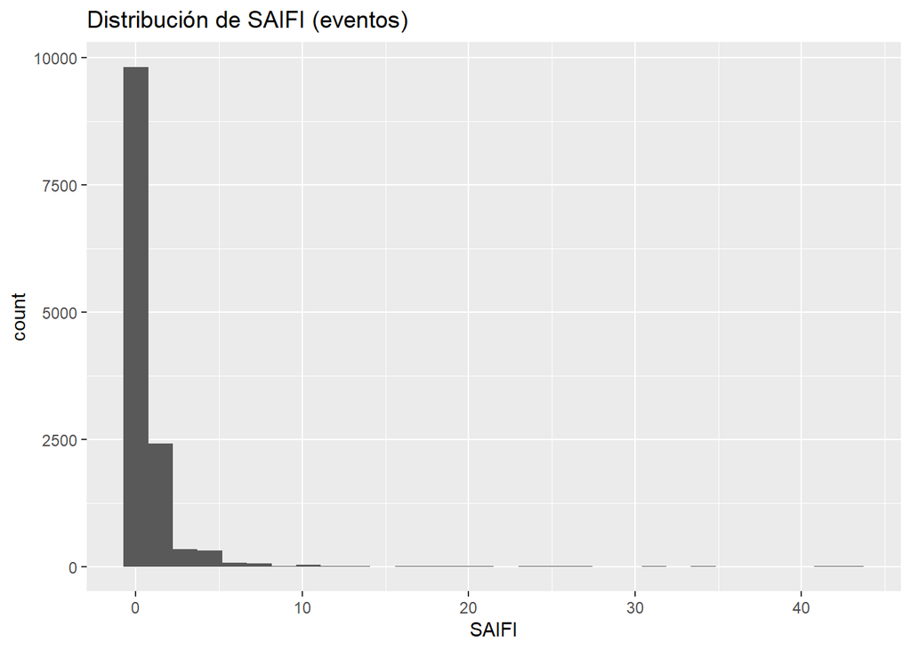

```r
ggplot(panel_semana, aes(x = SAIFI)) +
  geom_histogram(bins = 30) +
  ggtitle("Distribución de SAIFI (eventos)")
```

## Distribución de duración

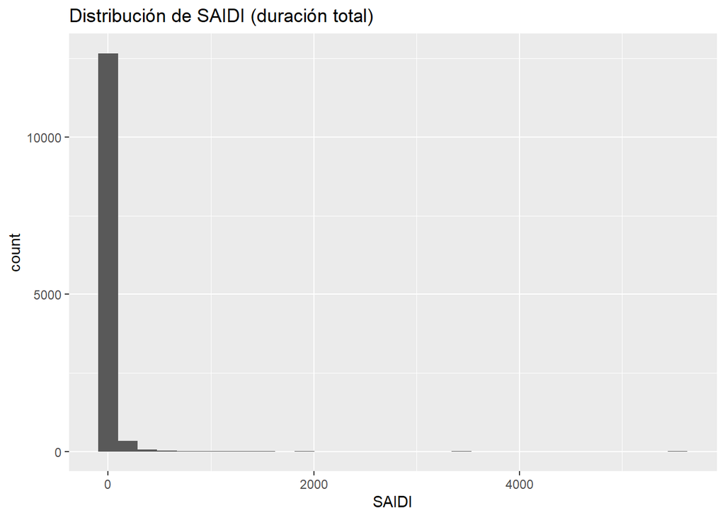

```r
ggplot(panel_semana, aes(x = SAIDI)) +
  geom_histogram(bins = 30) +
  ggtitle("Distribución de SAIDI (duración total)")
```

# 6. Matriz de correlación: SAIFI vs. variables climáticas

```r
vars_clima <- panel_semana %>%
  dplyr::select(
    SAIFI,
    temp_media_semana,
    temp_max_semana,
    temp_min_semana,
    precip_total_semana,
    humedad_media_semana,
    viento_medio_semana,
    viento_max_semana,
    lluvia_intensa,
    calor_extremo,
    viento_fuerte
  )

cor_matrix <- cor(vars_clima, use = "complete.obs")
round(cor_matrix, 3)
```

```
##                       SAIFI temp_media_semana temp_max_semana temp_min_semana
## SAIFI                 1.000             0.015           0.008           0.023
## temp_media_semana     0.015             1.000           0.983           0.971
## temp_max_semana       0.008             0.983           1.000           0.935
## temp_min_semana       0.023             0.971           0.935           1.000
## precip_total_semana   0.027            -0.185          -0.211          -0.077
## humedad_media_semana  0.007            -0.747          -0.781          -0.608
## viento_medio_semana   0.097            -0.729          -0.695          -0.777
## viento_max_semana     0.101            -0.727          -0.689          -0.773
## lluvia_intensa       -0.002            -0.103          -0.125          -0.028
## calor_extremo        -0.023             0.493           0.503           0.440
## viento_fuerte         0.049            -0.397          -0.397          -0.409
##                      precip_total_semana humedad_media_semana
## SAIFI                              0.027                0.007
## temp_media_semana                 -0.185               -0.747
## temp_max_semana                   -0.211               -0.781
## temp_min_semana                   -0.077               -0.608
## precip_total_semana                1.000                0.539
## humedad_media_semana               0.539                1.000
## viento_medio_semana               -0.092                0.290
## viento_max_semana                 -0.081                0.292
## lluvia_intensa                     0.793                0.332
## calor_extremo                     -0.155               -0.466
## viento_fuerte                     -0.081                0.180
##                      viento_medio_semana viento_max_semana lluvia_intensa
## SAIFI                              0.097             0.101         -0.002
## temp_media_semana                 -0.729            -0.727         -0.103
## temp_max_semana                   -0.695            -0.689         -0.125
## temp_min_semana                   -0.777            -0.773         -0.028
## precip_total_semana               -0.092            -0.081          0.793
## humedad_media_semana               0.290             0.292          0.332
## viento_medio_semana                1.000             0.987         -0.077
## viento_max_semana                  0.987             1.000         -0.073
## lluvia_intensa                    -0.077            -0.073          1.000
## calor_extremo                     -0.321            -0.321         -0.089
## viento_fuerte                      0.563             0.579         -0.065
##                      calor_extremo viento_fuerte
## SAIFI                       -0.023         0.049
## temp_media_semana            0.493        -0.397
## temp_max_semana              0.503        -0.397
## temp_min_semana              0.440        -0.409
## precip_total_semana         -0.155        -0.081
## humedad_media_semana        -0.466         0.180
## viento_medio_semana         -0.321         0.563
## viento_max_semana           -0.321         0.579
## lluvia_intensa              -0.089        -0.065
## calor_extremo                1.000        -0.109
## viento_fuerte               -0.109         1.000
```

## Visualización

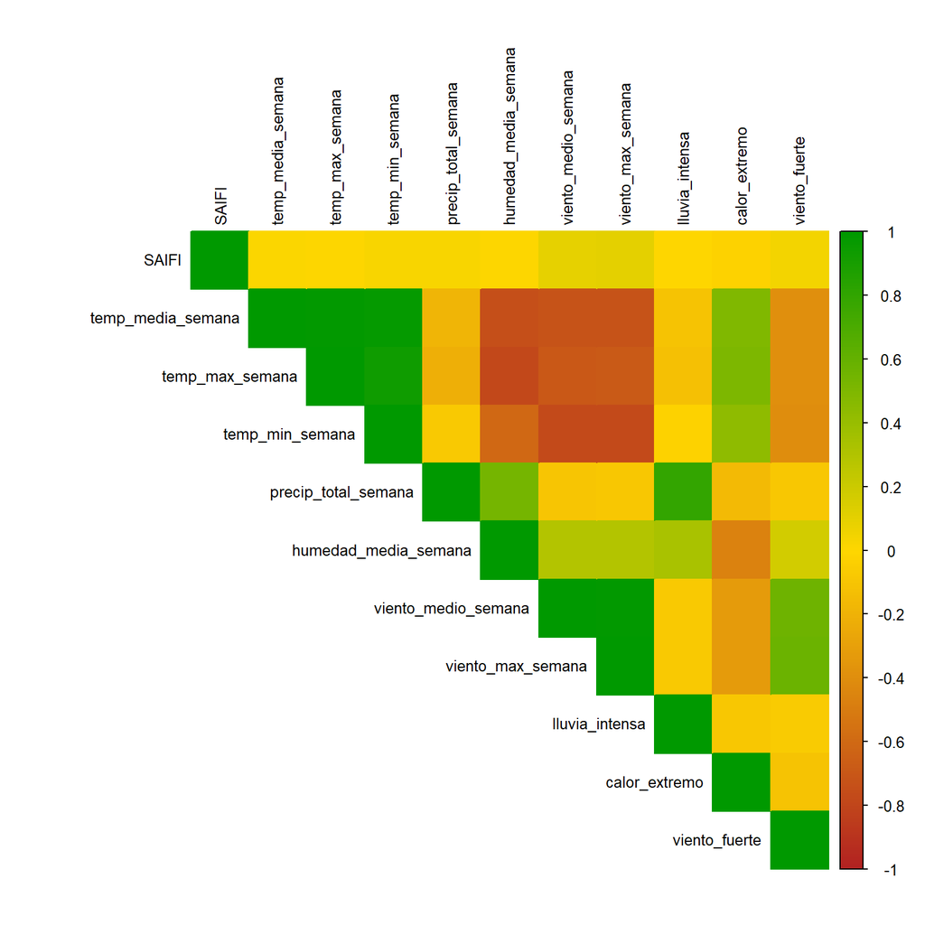

```r
corrplot(
  cor_matrix,
  method = "color",
  type = "upper",
  tl.col = "black",
  tl.cex = 0.8,
  number.cex = 0.7,
  col = colorRampPalette(c("#B22222", "#FFD700", "#009900"))(200)
)
```

## Matriz de dispersión (pairsplot)

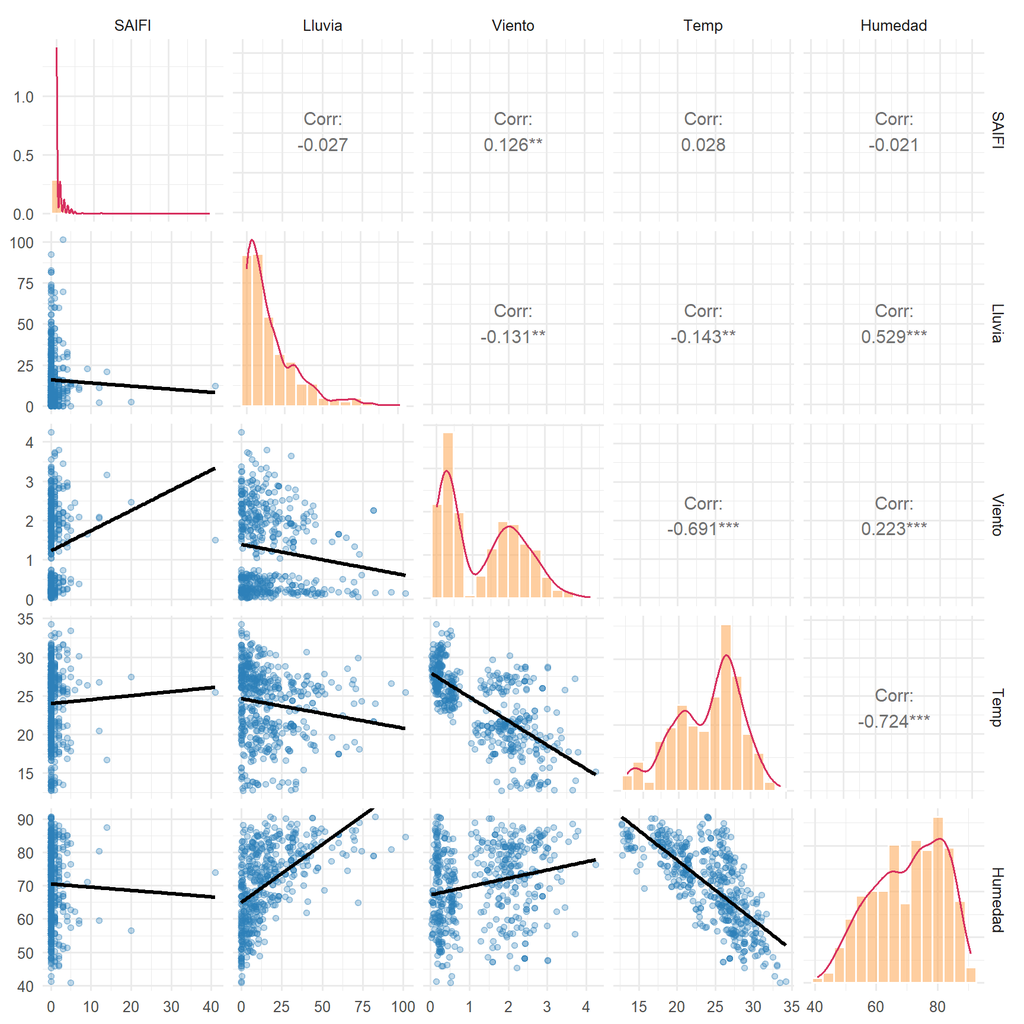

```r
combo_diag <- function(data, mapping, ...) {
  ggplot(data = data, mapping = mapping) +
    geom_histogram(aes(y = after_stat(density)),
                   bins = 15,
                   fill = "#fdae61",
                   alpha = 0.6,
                   color = "white") +
    geom_density(color = "#d7305f", linewidth = 0.6)
}

vars_saifi <- panel_semana %>%
  slice_sample(n = 500) %>%
  dplyr::select(
    SAIFI,
    precip_total_semana,
    viento_max_semana,
    temp_media_semana,
    humedad_media_semana
  ) %>%
  rename(
    SAIFI = SAIFI,
    Lluvia = precip_total_semana,
    Viento = viento_max_semana,
    Temp = temp_media_semana,
    Humedad = humedad_media_semana
  )

ggpairs(
  vars_saifi,
  lower = list(
    continuous = wrap("smooth",
                      alpha = 0.3,
                      color = "#2c7fb8",
                      se = FALSE)
  ),
  diag = list(
    continuous = combo_diag
  ),
  upper = list(
    continuous = wrap("cor", size = 4)
  )
) +
  theme_minimal(base_size = 12)
```

# 7. Matriz de correlación: SAIDI vs. variables climáticas

```r
vars_clima_saidi <- panel_semana %>%
  dplyr::select(
    SAIDI,
    temp_media_semana,
    temp_max_semana,
    temp_min_semana,
    precip_total_semana,
    humedad_media_semana,
    viento_medio_semana,
    viento_max_semana,
    lluvia_intensa,
    calor_extremo,
    viento_fuerte
  )

cor_matrix_saidi <- cor(vars_clima_saidi, use = "complete.obs")
```

## Pairsplot SAIDI

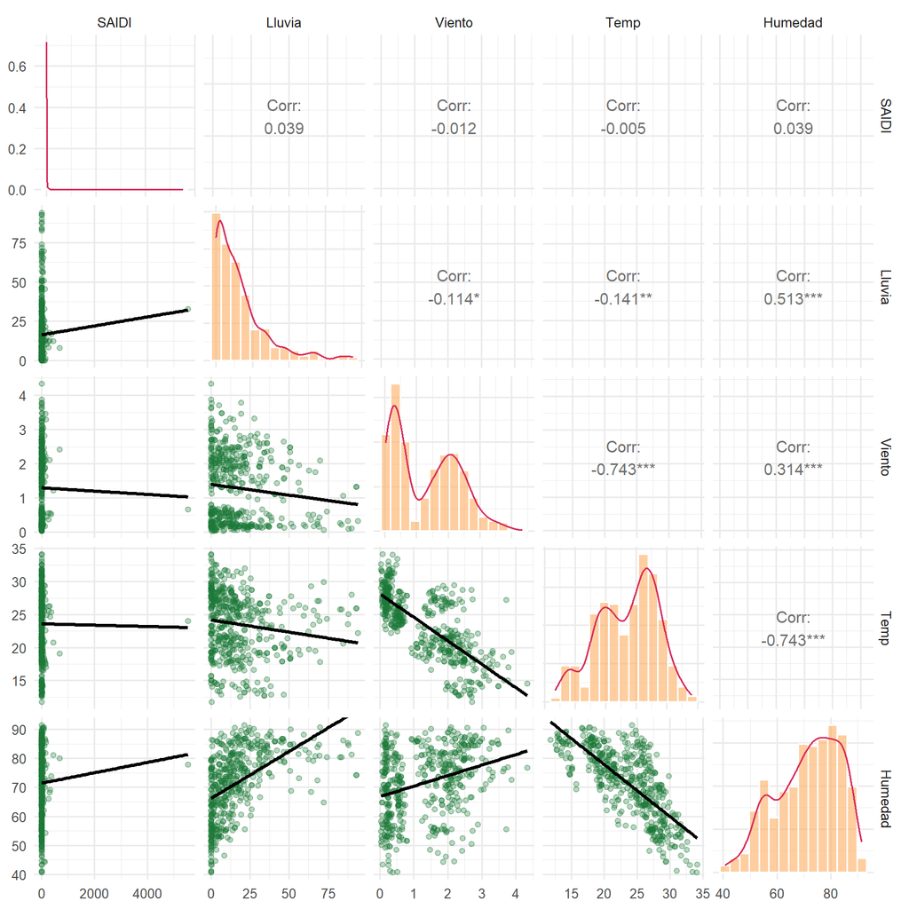

```r
vars_saidi <- panel_semana %>%
  slice_sample(n = 500) %>%
  dplyr::select(
    SAIDI,
    precip_total_semana,
    viento_max_semana,
    temp_media_semana,
    humedad_media_semana
  ) %>%
  rename(
    SAIDI = SAIDI,
    Lluvia = precip_total_semana,
    Viento = viento_max_semana,
    Temp = temp_media_semana,
    Humedad = humedad_media_semana
  )

ggpairs(
  vars_saidi,
  lower = list(
    continuous = wrap("smooth",
                      alpha = 0.3,
                      color = "#1b7837",
                      se = FALSE)
  ),
  diag = list(
    continuous = combo_diag
  ),
  upper = list(
    continuous = wrap("cor", size = 4)
  )
) +
  theme_minimal(base_size = 12)
```

## Visualización con escala distinta

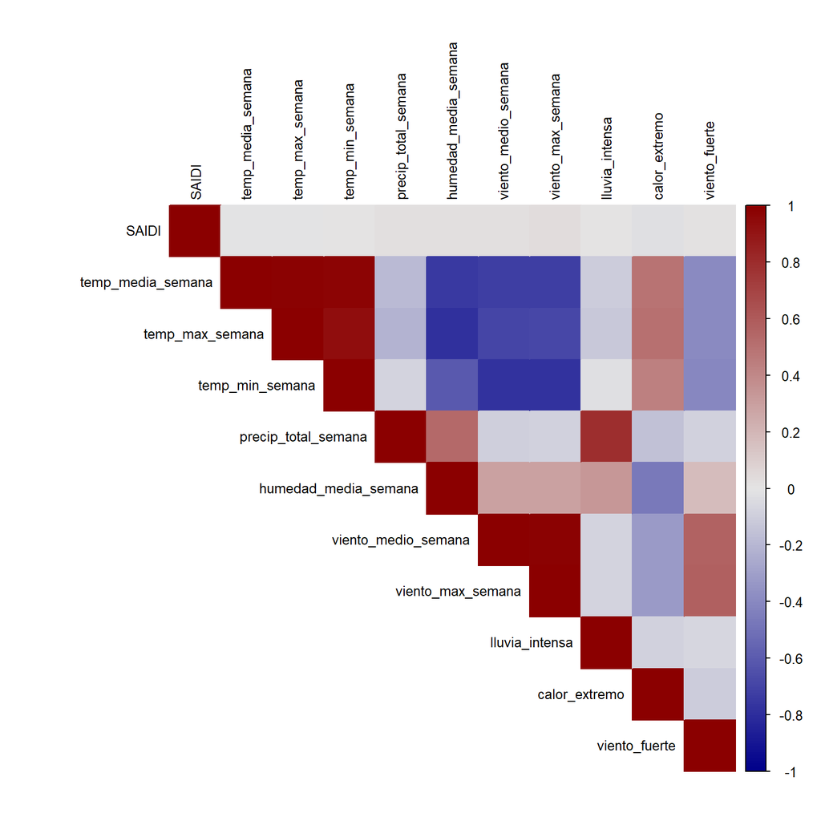

```r
corrplot(
  cor_matrix_saidi,
  method = "color",
  type = "upper",
  col = colorRampPalette(c("darkblue", "gray90", "darkred"))(200),
  tl.col = "black",
  tl.cex = 0.8,
  number.cex = 0.7
)
```

# 8. Incorporación de rezagos temporales

```r
panel_semana <- panel_semana %>%
  arrange(id_cuadrante, semana) %>%
  group_by(id_cuadrante) %>%
  mutate(
    lluvia_lag1 = lag(precip_total_semana, 1),
    viento_lag1 = lag(viento_max_semana, 1),
    eventos_lag1 = lag(SAIFI, 1)
  ) %>%
  ungroup()
```

## Exportación

Se exporta el panel con rezagos, insumo del siguiente documento (`Etapa4_02_rezagos_SAIDI.Rmd`).

```r
saveRDS(panel_semana, file.path(UBICACION_DATA, "panel_semana_con_rezagos.rds"))
cat(sprintf("panel_semana_con_rezagos exportado: %d filas x %d columnas\n",
            nrow(panel_semana), ncol(panel_semana)))
```

```
## panel_semana_con_rezagos exportado: 13100 filas x 24 columnas
```